# 260131 - DESeq2 Raw count normalization and DEG

This script is to take ‘raw count’ RNAseq that could come from Novogene or could be retrieved from previously published data.

You will need a Counts matrix and a metadata file

*Important steps:* 1. In your Novogene results folder, go to ‘3.Quant’ - ‘1.Count’ and copy the ‘gene_count.xlsx’ file into your working directory for this script. Change the top row (column names which are your samples) to S1-S(however many samples you have) with capital S and save the file as a .csv, see example in this directory. 2. Make a metadata file that explains what each sample is and also corresponds to S1-S(however many samples you have), see example in this directory as it needs the same headings. 3. Adjust the script near the start to however many samples are in your counts file. 4. Make sure you are using the right species database (Mm (mouse) vs Hs (human)). 5. List all of the group-group comparisons that you want to analyze (best to just run all comparisons so you have them) 4. If these are right, the script should work.

*Output (what you will get):* - .csv files that contain your normalized counts. I have put three different methods of normalized counts in this script, and playing around found that they all produce near identical results in downstream analysis. I use the “normalized_counts.csv” for subsequent scripts. - A boxplot of the median counts for each sample. - A boxplot comparison of how the normalization process brings in the library size range compared to the raw counts data (this is just proof of concept that the idea of normalization is to correct for differences in sequencing depth between samples). - .csv and .xlsx files of differential gene expression results for each comparison that you choose. One file has ’_sig’ as it is the list of only significant genes with FDR padj < 0.05 and an |log2FC|>1. - .rds R object containing the differential gene expression results for analysis later in pipeline.

First step is to load in everything and run DESeq2. This normalizes counts and runs DEG analysis which all get stored in the DESeq object (dds) which can be accessed throughout the script. **NOTE** DESeq2 naturally uses a reference group (control group). Depending on your experiment, you will have multiple comparisons you want to make and may want to adjust the control group. For this you have to rerun DESeq2 and specify your control group (which we do later in the script). But we will use the main control group to start off with and do those comparisons first.

```r
head(normalized_counts)
```

```
                Membrane_96     Blood_96 Membrane_97     Blood_97 Membrane_95 Blood_95
ENSG00000198804   335470.82 5.923951e+04    317877.7 8.858455e+04  564585.360 270657.8
ENSG00000210082   178589.16 9.310517e+04    153252.0 8.286663e+04  139725.953 633832.9
ENSG00000156508   211282.86 2.241760e+05    189421.4 2.040713e+05   24564.573 211999.3
ENSG00000108821   334361.84 1.080658e+00    451869.0 8.470991e-01  592120.790      0.0
ENSG00000166710    82356.15 3.978734e+05    106593.6 1.963415e+05    4244.902 253409.7
ENSG00000198886   193022.22 3.004986e+04    186080.8 5.395683e+04  656339.520 181314.0
```

I want a quick visualization of the normalized counts.

```r
# Define output file
png("Plots/rlog_boxplot.png", width = 800, height = 600)

# Create a boxplot of the rlog-transformed counts
boxplot(rlog_counts,
        main = "Boxplot of Rlog Transformed Counts",
        xlab = "Samples",
        ylab = "Rlog Counts",
        las = 2)  # Rotate axis labels for better readability

# Close the graphics device
dev.off()
```

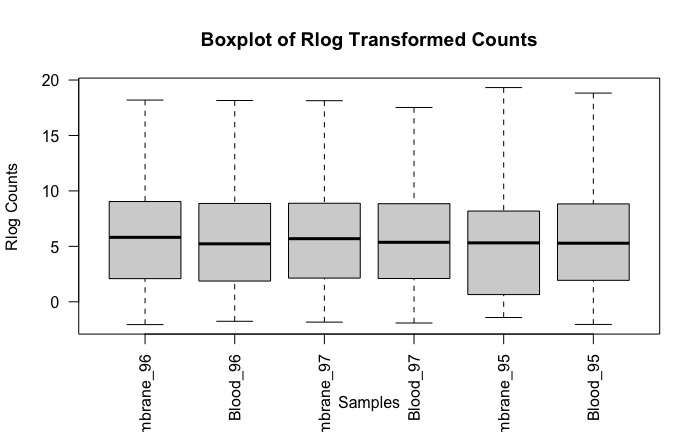

```r
boxplot(rlog_counts,
        main = "Boxplot of Rlog Transformed Counts",
        xlab = "Samples",
        ylab = "Rlog Counts",
        las = 2)  # Rotate axis labels for better readability
```

The black median line in the boxplot should line up really well after normalization

I want a plot to see what the library size looks like before and after normalization.

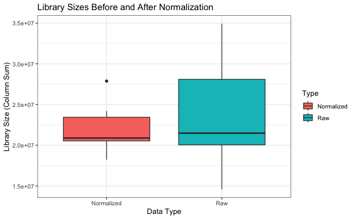

```r
# Calculate library sizes for raw counts
raw_library_sizes <- colSums(counts(dds, normalized=FALSE))

# Calculate library sizes for normalized counts
normalized_library_sizes <- colSums(counts(dds, normalized=TRUE))

# Create a data frame for plotting
library_size_df <- data.frame(
  Sample = rep(colnames(dds), 2),
  LibrarySize = c(raw_library_sizes, normalized_library_sizes),
  Type = rep(c("Raw", "Normalized"), each = ncol(dds))
)

# Create a box plot of library sizes
plot <- ggplot(library_size_df, aes(x = Type, y = LibrarySize, fill = Type)) +
  geom_boxplot() +
  labs(title = "Library Sizes Before and After Normalization",
       x = "Data Type",
       y = "Library Size (Column Sum)") +
  theme_bw()

plot

# Save the plot
ggsave("Plots/library_size_boxplot.png", plot = plot, width = 8, height = 6, dpi = 300)
```

The next step is to extract the differential gene expression results from the dds object. First use the apeglm method to apply log2 fold change shrinkage. Shrinkage reduces exaggerated fold changes that often occur in genes with very low read counts or high variability. For example, a gene with 10 counts in one group and 2 in another may show a large fold change, but this estimate is very uncertain and may not be biologically meaningful. Shrinkage makes these fold changes more conservative and reliable, especially for low-count genes, while leaving well-expressed genes largely unchanged. Importantly, shrinkage does not affect p-values — it only improves the accuracy of the fold change estimates. Because of this, you may see fewer genes passing fold-change cutoffs compared to some external pipelines (e.g., Novogene), but the reported effect sizes are generally more trustworthy.

We also want to create a really detailed DEG output spreadsheet mimicking what Novogene provides and will work with the downstream scripts we already have. Here is a function that can generate one of those spreadsheets:

Here we have created a function that can be run easily by just inputing the two groups that you want to compare. It is critical you know which group you want to be the control group in your comparison.

```r
run_DEG <- function(dds, metadata, group1, group2, base_outdir = "Results/DEG") {

  message("Running DEG: ", group1, " vs ", group2)

  # Create a folder for the results sheet to go into
  comp_name <- paste0(group1, "_vs_", group2)
  outdir <- file.path(base_outdir, comp_name)
  dir.create(outdir, recursive = TRUE, showWarnings = FALSE)

  ###

  # Set the control group as the reference and rerun DESeq2
  dds$Group <- relevel(dds$Group, ref = group2)
  dds <- DESeq(dds)

  coef_name <- paste0("Group_", group1, "_vs_", group2)

  if (!coef_name %in% resultsNames(dds)) {
    stop(paste("Coefficient not found:", coef_name)) # Sanity check to make sure you input your group names correctly
  }

  ###

  # Extract the shrinked DEG results from the dds object
  res <- lfcShrink(dds, coef = coef_name, type = "apeglm")
  res_df <- as.data.frame(res)
  res_df$gene_id <- rownames(res_df)

  colnames(res_df)[colnames(res_df) == "baseMean"] <- "ExperimentMean" # I renamed this to make some more sense

  ###

  # Extract normalized counts (only samples in these two groups) to add to the final output sheet
  samples_keep <- metadata$SampleLabel[metadata$Group %in% c(group1, group2)]

  norm_counts <- as.data.frame(counts(dds, normalized = TRUE)[, samples_keep, drop = FALSE])
  norm_counts$gene_id <- rownames(norm_counts)

  # Get group norm count averages to add to the spreadsheet (need to specify your groups here)
  groups <- metadata$Group
  names(groups) <- metadata$SampleLabel

  norm_counts[[group1]] <- rowMeans(norm_counts[, names(groups[groups == group1]), drop = FALSE])
  norm_counts[[group2]] <- rowMeans(norm_counts[, names(groups[groups == group2]), drop = FALSE])

  # Merge counts into the DEG results dataframe
  res_df <- merge(res_df, norm_counts, by = "gene_id", all.x = TRUE)

  ###

  # # Get gene symbols (org.Hs.eg.db) to add to spreadhseet
  gene_symbols <- mapIds(org.Hs.eg.db, # Need to adjust if using mouse vs human data
                         keys = res_df$gene_id,
                         column = "SYMBOL",
                         keytype = "ENSEMBL",
                         multiVals = "first")

  res_df$gene_name <- gene_symbols

  # Get genomic annotation (biomaRt) to add to spreadsheet
  mart <- useEnsembl(biomart = "genes",
                     dataset = "hsapiens_gene_ensembl") # Need to adjust if using mouse vs human data

  annotation_df <- getBM(
    attributes = c("ensembl_gene_id",
                   "chromosome_name",
                   "start_position",
                   "end_position",
                   "strand",
                   "gene_biotype",
                   "description"),
    filters = "ensembl_gene_id",
    values = res_df$gene_id,
    mart = mart
  )

  colnames(annotation_df) <- c("gene_id",
                               "gene_chr",
                               "gene_start",
                               "gene_end",
                               "gene_strand",
                               "gene_biotype",
                               "gene_description")

  annotation_df$gene_length <- annotation_df$gene_end - annotation_df$gene_start

  # Merge into the results dataframe
  master_df <- merge(res_df, annotation_df, by = "gene_id", all.x = TRUE)



  # Reorder the dataframe for saving
  final_order <- c("gene_id",
                   samples_keep,
                   group1,
                   group2,
                   "ExperimentMean",
                   "log2FoldChange",
                   "lfcSE",
                   "pvalue",
                   "padj",
                   "gene_name",
                   "gene_chr",
                   "gene_start",
                   "gene_end",
                   "gene_strand",
                   "gene_length",
                   "gene_biotype",
                   "gene_description")

  master_df <- master_df[, final_order]
  master_df <- master_df[order(master_df$padj), ] # Sort based on significance

  ###

 # Save the object for downstream analysis - e.g. transcription factor inference
  tf_objects <- list(
    dds = dds,
    res_raw = results(dds, name = coef_name),
    res_shrunk = res,
    contrast = c(group1, group2),
    coef = coef_name,
    organism = "human",
    date = Sys.Date()
  )

  tf_rds <- file.path(outdir, paste0(comp_name, "_DEG_object.rds"))
  saveRDS(tf_objects, tf_rds)


  # Export files (both xlsx for sharing and csv for further analysis)
  full_xlsx <- file.path(outdir, paste0(comp_name, "_deg", ".xlsx"))
  full_csv  <- file.path(outdir, paste0(comp_name, "_deg", ".csv"))

  sig_df <- subset(master_df, padj < 0.05 & abs(log2FoldChange) > 1) # Additional file for

  sig_xlsx <- file.path(outdir, paste0(comp_name, "_deg_sig", ".xlsx"))
  sig_csv  <- file.path(outdir, paste0(comp_name, "_deg_sig", ".csv"))

  write.xlsx(master_df, full_xlsx, rowNames = FALSE)
  write.csv(master_df, full_csv, row.names = FALSE)

  write.xlsx(sig_df, sig_xlsx, rowNames = FALSE)
  write.csv(sig_df, sig_csv, row.names = FALSE)

  message("Saved results in folder: ", outdir)

  return(master_df)
}
```

List all of the combinations that you want to run here and it will automatically populate into your Results/DEG/ folder! Make sure to check them carefully! Add more combinations if needed. *Critical* - The second listed group will be the control of the comparison which you need to know to read the direction of fold change accurately

```r
run_DEG(dds, metadata, "Membrane", "Blood")
```

[output not shown]

|  | gene_id | Membrane_96 | Blood_96 | Membrane_97 | Blood_97 | Membrane_95 | Blood_95 | Membrane | Blood | ExperimentMean | log2FoldChange | lfcSE | pvalue | padj | gene_name | gene_chr | gene_start | gene_end | gene_strand | gene_length | gene_biotype | gene_description |
| --- | --- | --- | --- | --- | --- | --- | --- | --- | --- | --- | --- | --- | --- | --- | --- | --- | --- | --- | --- | --- | --- | --- |
| 5613 | ENSG00000129538 | 2.583453e+04 | 1.945184e+01 | 3.249704e+04 | 1.694198e+01 | 4.480199e+04 | 2.077827e+01 | 3.437785e+04 | 1.905737e+01 | 17198.45454 | 10.7603806 | 0.5645620 | 3.713975e-82 | 8.457092e-78 | RNASE1 | 14 | 20801228 | 20802884 | -1 | 1656 | protein_coding | ribonuclease A family member 1, pancreatic [Source:HGNC Symbol;Acc:HGNC:10044] |
| 2260 | ENSG00000100979 | 2.773206e+04 | 2.161316e+01 | 2.667460e+04 | 2.541297e+01 | 1.675388e+04 | 3.047480e+01 | 2.372018e+04 | 2.583364e+01 | 11873.00590 | 9.7862642 | 0.5595584 | 1.989951e-69 | 2.265658e-65 | PLTP | 20 | 45897535 | 45912235 | -1 | 14700 | protein_coding | phospholipid transfer protein [Source:HGNC Symbol;Acc:HGNC:9093] |
| 7419 | ENSG00000141753 | 4.014158e+04 | 1.253563e+02 | 3.947821e+04 | 1.033461e+02 | 3.888514e+04 | 7.549439e+01 | 3.950164e+04 | 1.013989e+02 | 19801.52045 | 8.5576052 | 0.4969064 | 1.026694e-67 | 7.792952e-64 | IGFBP4 | 17 | 40442913 | 40460822 | 1 | 17909 | protein_coding | insulin like growth factor binding protein 4 [Source:HGNC Symbol;Acc:HGNC:5473] |
| 6340 | ENSG00000134871 | 4.073096e+04 | 3.241974e+00 | 1.985594e+04 | 2.541297e+00 | 2.374582e+04 | 1.385218e+00 | 2.811090e+04 | 2.389497e+00 | 14056.64696 | 13.4635666 | 0.8441101 | 1.457308e-58 | 8.296090e-55 | COL4A2 | 13 | 110305778 | 110513209 | 1 | 207431 | protein_coding | collagen type IV alpha 2 chain [Source:HGNC Symbol;Acc:HGNC:2203] |
| 3323 | ENSG00000108821 | 3.343618e+05 | 1.080658e+00 | 4.518690e+05 | 8.470991e-01 | 5.921208e+05 | 0.000000e+00 | 4.594505e+05 | 6.425857e-01 | 229725.59493 | 19.4420352 | 1.2154789 | 3.936904e-57 | 1.792945e-53 | COL1A1 | 17 | 50184101 | 50201704 | -1 | 17603 | protein_coding | collagen type I alpha 1 chain [Source:HGNC Symbol;Acc:HGNC:2197] |
| 5739 | ENSG00000130635 | 2.030925e+04 | 5.403290e+00 | 2.553415e+04 | 8.470991e+00 | 2.187301e+04 | 1.385218e+00 | 2.257214e+04 | 5.086500e+00 | 11288.61117 | 12.0371139 | 0.7996715 | 1.077232e-52 | 4.088276e-49 | COL5A1 | 9 | 134641724 | 134844843 | 1 | 203119 | protein_coding | collagen type V alpha 1 chain [Source:HGNC Symbol;Acc:HGNC:2209] |
| 7447 | ENSG00000142156 | 5.382131e+04 | 2.917777e+01 | 6.894047e+04 | 9.911060e+01 | 6.303460e+04 | 5.333090e+01 | 6.193212e+04 | 6.053975e+01 | 30996.33149 | 9.9095448 | 0.6763196 | 8.595813e-50 | 2.796218e-46 | COL6A1 | 21 | 45981727 | 46005050 | 1 | 23323 | protein_coding | collagen type VI alpha 1 chain [Source:HGNC Symbol;Acc:HGNC:2211] |
| 5490 | ENSG00000128383 | 7.113217e+01 | 6.955115e+03 | 6.731153e+01 | 6.434565e+03 | 6.312833e+01 | 6.137902e+03 | 6.719068e+01 | 6.509194e+03 | 3288.19231 | -6.5311491 | 0.4590793 | 4.146314e-47 | 1.180197e-43 | APOBEC3A | 22 | 38952741 | 38963184 | 1 | 10443 | protein_coding | apolipoprotein B mRNA editing enzyme catalytic subunit 3A [Source:HGNC Symbol;Acc:HGNC:17343] |
| 3888 | ENSG00000113657 | 4.000338e+03 | 6.483948e+00 | 3.580012e+03 | 3.388397e+00 | 2.429484e+03 | 7.618700e+00 | 3.336611e+03 | 5.830348e+00 | 1671.22077 | 9.0558181 | 0.6885032 | 1.427387e-40 | 3.611449e-37 | DPYSL3 | 5 | 147390808 | 147510543 | -1 | 119735 | protein_coding | dihydropyrimidinase like 3 [Source:HGNC Symbol;Acc:HGNC:3015] |
| 1311 | ENSG00000077942 | 1.077347e+04 | 0.000000e+00 | 1.260745e+04 | 8.470991e-01 | 1.391501e+04 | 1.385218e+00 | 1.243198e+04 | 7.441058e-01 | 6216.36182 | 13.7377119 | 1.0377307 | 4.746672e-39 | 1.080865e-35 | FBLN1 | 22 | 45502238 | 45601981 | 1 | 99743 | protein_coding | fibulin 1 [Source:HGNC Symbol;Acc:HGNC:3600] |

[output cut: 990 more lines]

**NOTE** using ‘apeglm’ for LFC shrinkage. If used in published research, please cite: Zhu, A., Ibrahim, J.G., Love, M.I. (2018) Heavy-tailed prior distributions for sequence count data: removing the noise and preserving large differences. Bioinformatics. https://doi.org/10.1093/bioinformatics/bty895

I like to finish with the session info command as it lists all the versions that were used at the time of analysis. The other lines will save the output as a text file with the date that the command was run.

[session information not shown]

```r
# Create filename with date prefix
filename <- paste0(Sys.Date(), "_sessionInfo.txt")

# Save sessionInfo output
capture.output(sessionInfo(), file = filename)
```